# akinzer_05

Andrew Kinzer

February 20, 2017

# Exercise 1

The code below loads the “Faithful” dataset into R. Then, the cor() fuction calculates the correlation coefficients between the waiting time between eruptions and the duration of the eription of Old Faithful.

```r
cor(faithful[, c("eruptions", "waiting")], use="na.or.complete")
```

```
##           eruptions   waiting
## eruptions 1.0000000 0.9008112
## waiting   0.9008112 1.0000000
```

[figure not shown]

# Exercise 2

Below is a second linear model, testing the relationship between Ozone and Temperature

```r
mod2=lm(Temp~Ozone, data=airquality)
summary(mod2)
```

```
##
## Call:
## lm(formula = Temp ~ Ozone, data = airquality)
##
## Residuals:
##     Min      1Q  Median      3Q     Max
## -22.147  -4.858   1.828   4.342  12.328
##
## Coefficients:
##             Estimate Std. Error t value Pr(>|t|)
## (Intercept) 69.41072    1.02971   67.41   <2e-16 ***
## Ozone        0.20081    0.01928   10.42   <2e-16 ***
## ---
## Signif. codes:  0 '***' 0.001 '**' 0.01 '*' 0.05 '.' 0.1 ' ' 1
##
## Residual standard error: 6.819 on 114 degrees of freedom
##   (37 observations deleted due to missingness)
## Multiple R-squared:  0.4877, Adjusted R-squared:  0.4832
## F-statistic: 108.5 on 1 and 114 DF,  p-value: < 2.2e-16
```

The summary table above is telling us that for every one (1) increase in unit of Ozone, our Temperature will increase 0.2 units. The p-value of 2e-16 indicates that they are statistically significantly correlated. The adjusted r-squared value of 0.483 indicates that 48% of our temperature increase can be explained by an increase in ozone.

This relationship is further demonstrated by the plot below.

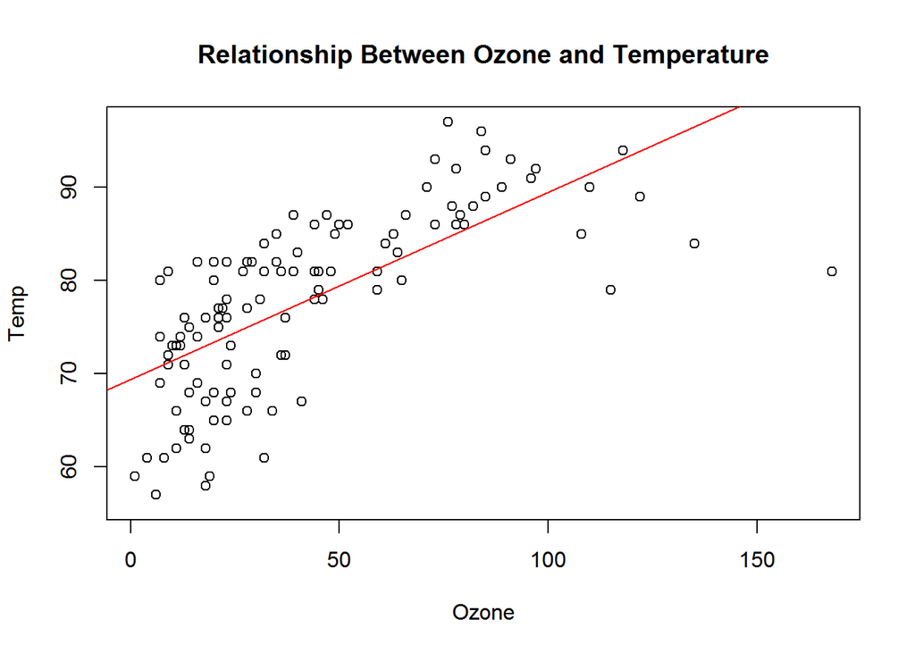

Below is a linear model examining whether we see a longer eruption time if you wait longer between eruptions.

```r
mod3=lm(eruptions~waiting, data=faithful)
summary(mod3)
```

```
##
## Call:
## lm(formula = eruptions ~ waiting, data = faithful)
##
## Residuals:
##      Min       1Q   Median       3Q      Max
## -1.29917 -0.37689  0.03508  0.34909  1.19329
##
## Coefficients:
##              Estimate Std. Error t value Pr(>|t|)
## (Intercept) -1.874016   0.160143  -11.70   <2e-16 ***
## waiting      0.075628   0.002219   34.09   <2e-16 ***
## ---
## Signif. codes:  0 '***' 0.001 '**' 0.01 '*' 0.05 '.' 0.1 ' ' 1
##
## Residual standard error: 0.4965 on 270 degrees of freedom
## Multiple R-squared:  0.8115, Adjusted R-squared:  0.8108
## F-statistic:  1162 on 1 and 270 DF,  p-value: < 2.2e-16
```

This summary is telling us that the y-intercept is -1.87, and that the significant p-value is simply showin that the intercept is significantly different than 0. The estimate of 0.076 for the “waiting” variable indicates that for every increase in one unit ofWaiting time, the eruption timte increases by 0.076 units, which we cna see by the p-value of 2.2e-16, is a significant relationship. The adjusted r-squared value of 0.81 tells us that 81% of the change eruption time is related to the time spent waiting between eruptions.

The relationship is further shown through the points, plotted below.

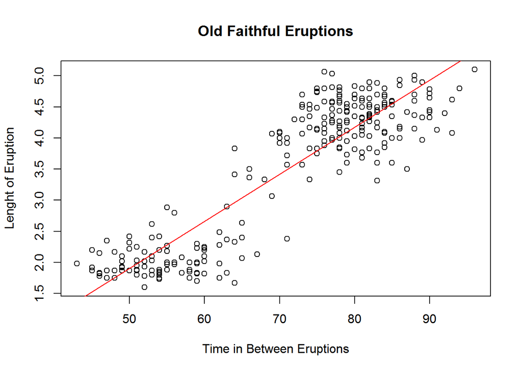